# R Programming

R LAS

December 12, 2015

# Functions: Writing functions

The general form of an R function is `fname<-function(arg1,arg2,etc) function.body`.

### Simple Example

```r
mySqrt<-function(x) sqrt(x)

mySqrt(2)
```

```
## [1] 1.414214
```

```r
mySqrt
```

```
## function(x) sqrt(x)
```

# Functions: Writing functions

Functions belong to their own class.

```r
class(mySqrt)
```

```
## [1] "function"
```

What’s wrong with this?

```r
mySqrt<-function(x) {
  y<-sqrt(x)
}

mySqrt(2)
```

# Functions: Writing functions

Use `return` if you want to return a variable.

```r
mySqrt<-function(x) {
  y<-sqrt(x)
  return(y)
}

mySqrt(2)
```

```
## [1] 1.414214
```

# Functions: Named Arguments

If you want a default input, include it as an argument.

```r
mySqrt<-function(x=2) sqrt(x)

mySqrt()
```

```
## [1] 1.414214
```

# Functions: Passing optional arguments

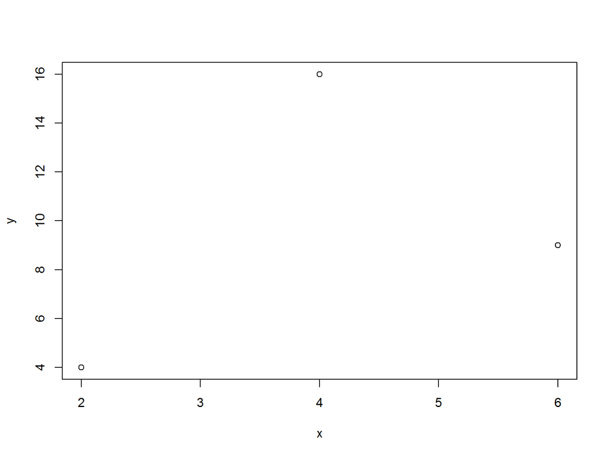

```r
myPlot<-function(x,y) plot(x=x,y=y)

myPlot(c(2,4,6),c(4,16,9))
```

# Functions: Passing optional arguments

This will error.

```r
myPlot(c(2,4,6),c(4,16,9),pch=19,col="red")
```

Add `...` to indicate optional arguments being passed.

```r
myPlot<-function(x,y,...) plot(x=x,y=y,...)
```

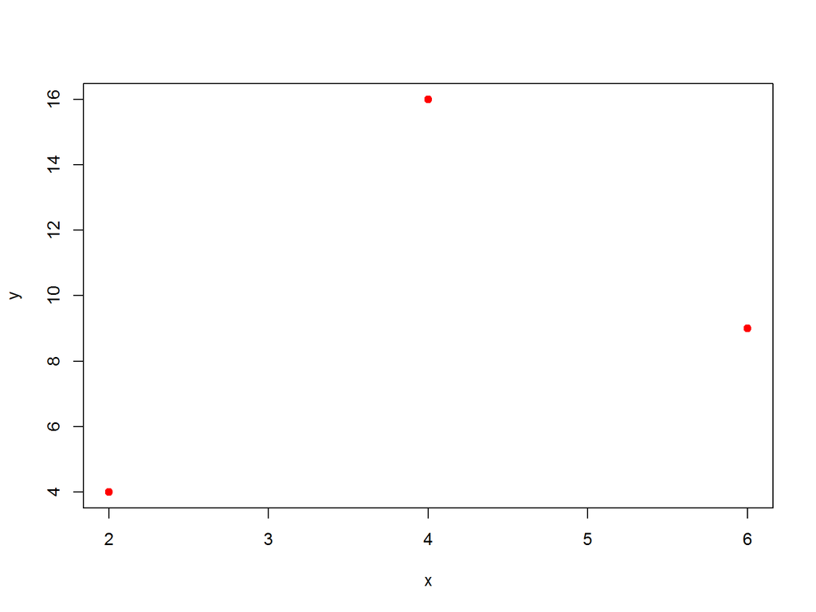

```r
myPlot(c(2,4,6),c(4,16,9),pch=19,col="red")
```

# Functions: Variables defined within a function are local.

```r
mySum<-function(x,y){
  z<-x+y
  return(z)
}
```

This will error.

```r
z
```

# Control Statements: For

```r
for (i in 1:5) cat(i^2,"\n")
```

```
## 1
## 4
## 9
## 16
## 25
```

Note: `cat` is a cruder form of output than `print`. `\n` is a carriage return.

# Control Statements: While

```r
x<-2

while (x <10) {
  cat(x,"\n")
  x<-x+2
  }
```

```
## 2
## 4
## 6
## 8
```

# Control Statements: If-then-else

```r
f1<-function(x){
  if (x<0) cat("x is negative") else cat("x is nonnegative")
}

f1(-2)
```

```
## x is negative
```

There’s also an `ifelse` function.

```r
myAbs<-function(x) ifelse(x<0,-x,x)
myAbs(-3)
```

```
## [1] 3
```

# Quadratic Formula

```r
myQuadratic<-function(a,b,c){
  if (a==0) {cat("Not a Quadratic Equation")}
    else
      {D<- b^2-4*a*c
      if (D<0) {cat("No Real Solutions")} else{
      assign("x1",(-b+sqrt(D))/(2*a))
      assign("x2",(-b-sqrt(D))/(2*a))
      cat(c(x1,x2),"are the real roots")
    }
  }
}
```

# Quadratic Formula

```r
myQuadratic(1,1,1)
```

```
## No Real Solutions
```

```r
myQuadratic(0,0,0)
```

```
## Not a Quadratic Equation
```

```r
myQuadratic(1,-5,6)
```

```
## 3 2 are the real roots
```

```r
myQuadratic(1,-4,4)
```

```
## 2 2 are the real roots
```

# Newton’s Method

The iterative formula for finding a root of $f(x)$ where the starting point $x_0$ is selected is given by. $x_{n+1} = x_n - \frac{f(x_n)}{f'(x_n)}$

So to determine the square root of $a$, we’ll use the formula $x_{n+1} = x_n -\frac{x_n^2 - a}{2x_n}$

# Graphical Interpretaion of Newton’s Method

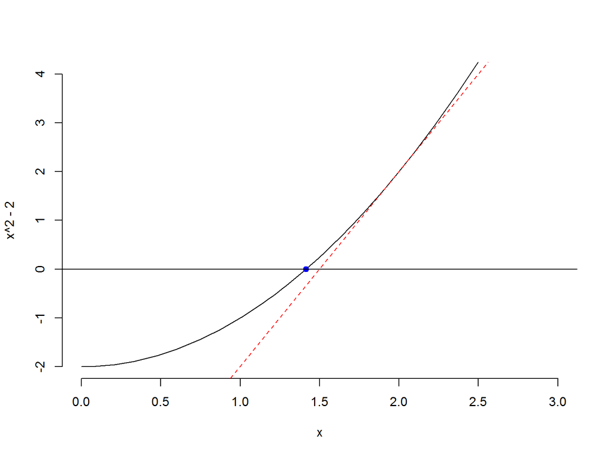

```r
curve(x^2-2,xlim=c(0,3),bty="n",ylim=c(-2,4))
points(x=sqrt(2),y=0,pch=19,col="blue")
abline(h=0)
abline(a=-6,b=4,col="red",lty="dashed")
```

# Newton’s Method

```r
Newton<-function(x,a) {x - (x^2-a)/(2*x)}

x<-2
for (i in 1:8){
  print(x,digits=22)
  x<-Newton(x,2)
}
```

```
## [1] 2
## [1] 1.5
## [1] 1.4166666666666667
## [1] 1.4142156862745099
## [1] 1.4142135623746899
## [1] 1.4142135623730951
## [1] 1.4142135623730949
## [1] 1.4142135623730951
```

# Newton’s Method

We’ll write a function that stops after a set number of iterations or successive iterations are within a certain tolerance of each other.

```r
mySqrt<-function(a,start=2,maxIter=10,maxDiff=.0001){

  n<-1
  x<-start
  diff=10000
  while(n<maxIter & diff>maxDiff){
    y<-x
    x<-Newton(x,a)
    diff=abs(x-y)
    n<-n+1
  }
  return(list(sqrt=x,iterations=n-1,difference=diff))
}
```

```r
mySqrt(2)
```

```
## $sqrt
## [1] 1.414214
##
## $iterations
## [1] 4
##
## $difference
## [1] 2.1239e-06
```

# Vectorized Programming: sapply

`sapply` returns a vector

```r
sapply(1:3,sqrt)
```

```
## [1] 1.000000 1.414214 1.732051
```

# Vectorized Programming: lapply

`lapply` returns a list

```r
lapply(1:3,sqrt)
```

```
## [[1]]
## [1] 1
##
## [[2]]
## [1] 1.414214
##
## [[3]]
## [1] 1.732051
```

# Compound Poisson-Gamma Distribution

$Y = X_1 + X_2 + \cdots + X_N$ where $N$ is Poisson with mean $\lambda$ and $X$ is gamma with parameters $\alpha$ and $\beta$.

- Generate 10000 random Poisson variables
- For each Poisson generate random Gamma
- Add up the Gamma values

```r
set.seed(6345789)
n1<-10000
poisMean<-3
p1<-rpois(n1,lambda=poisMean)
gammaShape<-3
gammaScale<-4
t1<-lapply(1:n1,function(i)
  sum(rgamma(p1[i],shape=gammaShape,scale=gammaScale)))
t1<-unlist(t1)
mean(t1)
```

```
## [1] 35.9197
```

# Parallel Processing

R is single threaded so if you want to make full use of other processors you have to do some parallel processing.

```r
library(parallel)
detectCores()
```

```
## [1] 4
```

The following command won’t work on Windows machines. It’ll use all the cores (if they’re available) on a Linux machine.

```r
t1<-mclapply(1:n1,function(i)
  sum(rgamma(p1[i],shape=gammaShape,scale=gammaScale)),
mc.cores=detectCores())
```

Per [this discussion](http://r.789695.n4.nabble.com/Programmaticly-finding-number-of-processors-by-R-code-td2953437.html) determining the number of cores isn’t as straightforward as you’d like it to be.

# Running your own server.

There are a number of ways to set up your own server and run RStudio server. Note that this isn’t free.

[Installing R & RStudio on a Rackspace Server](https://r-dir.com/blog/2014/04/installing-r-rstudio-on-rackspace.html)

[Setting up an AWS instance for R, RStudio, OpenCPU, or Shiny Server](http://ipub.com/aws/)

[Data Science Series: Standing up RStudio Server on Azure](https://channel9.msdn.com/Blogs/Windows-Azure/Data-Science-Series-Standing-up-%20RStudio-Server-on-Azure)

[How To Set Up RStudio On An Ubuntu Cloud Server](https://www.digitalocean.com/community/tutorials/how-to-set-up-rstudio-on-an-ubuntu-cloud-server)